# TFLink use case 2

Similarities and differences in the function of target genes of a nuclear hormone receptor, **unc-55** in *Caenorhabditis elegans* and in human

# 1 The aim of this use case

Here we investigate the functional diversity of target genes of a *nuclear hormone receptor* transcription factor, the **unc-55** in *Caenorhabditis elegans* (*C. elegans*) and in human. We perform *Gene Ontology* (*GO*) overrepresentation analyses of the target genes in the two species in order to identify shared functional roles that likely represent the ancestral function of **unc-55**. Furthermore, this comparison will yield insights into the potentially divergent roles **unc-55** play in these two distant animal groups.

# 2 Input data

Let’s download and read in to `R` the [*target gene interaction table* of the **unc-55** transcription factor in *Caenorhabditis elegans*](https://tflink.net/protein/g5ecr9/) and the [*target gene interaction table* of the **unc-55** ortholog **NR2F1** transcription factor in human](https://tflink.net/protein/p10589/) from the [TFLink](https://tflink.net/) website using the `read_tsv` command of the `tidyverse` package.

```r
library(tidyverse)
# C.elegans unc-55
Interaction_tab_Ce <- read_tsv("https://tflink.net/protein/g5ecr9/")
# human NR2F1
Interaction_tab_Hs <- read_tsv("https://tflink.net/protein/p10589/")
```

For the overrepresentation analyses we will need *background* genes sets. Therefore, we download all *C. elegans* and human target genes available at the [**Download** part of the TFLink](https://tflink.net/download/) website, and read it in with the `fread` command of the `data.table` package that reads huge tables effectively.

```r
library(data.table)

# Creating a list for the Uniprot IDs of the background genes
Background_Uniprot <- list()

# Background genes for C. elegans
Background_Uniprot$Ce <- fread(
  "TFLink_Caenorhabditis_elegans_interactions_All_simpleFormat_v1.0.tsv") %>%
  select(UniprotID.Target) %>%
  unique() %>%
  pull()

# Background genes for human
Background_Uniprot$Hs <- fread(
  "TFLink_Homo_sapiens_interactions_All_simpleFormat_v1.0.tsv") %>%
  select(UniprotID.Target) %>%
  unique() %>%
  pull()
```

# 3 *Gene ontology* overrepresentation analysis of target genes

To have an idea about the type of *Biological processes* the **unc-55** and the **NR2F1** transcription factors regulate we perform a *Gene ontology* (*GO*) overrepresentation analysis of their target genes using the `clusterProfiler` `R` `Bioconductor` package.

## 3.1 Translating the target genes and the background genes to *Entrez IDs*

First, we need to translate the *Uniprot IDs* of the target genes to *Entrez IDs* using the `bitr` function of the `clusterProfiler` package. For this we need to install another two `R` `Bioconductor` packages containing various biological identifiers: the `org.Ce.eg.db` and `org.Hs.eg.db`.

```r
library(clusterProfiler)

# Creating a list for the target genes
Genes_list <- list()

# Translating the target genes of C. elegans unc-55 to Entrez IDs
Genes_list$Ce_unc55 <- bitr(geneID = Interaction_tab_Ce$UniprotID.Target,
                            fromType = "UNIPROT",
                            toType = c("ENTREZID"),
                            OrgDb = "org.Ce.eg.db") %>%
  dplyr::select(ENTREZID) %>%
  unique() %>%
  pull()

# Translating the background genes of C. elegans to Entrez IDs
Genes_list$Ce_BG <- bitr(geneID = Background_Uniprot$Ce,
                            fromType = "UNIPROT",
                            toType = c("ENTREZID"),
                            OrgDb = "org.Ce.eg.db") %>%
  dplyr::select(ENTREZID) %>%
  unique() %>%
  pull()

# Translating the target genes of human NR2F1 to Entrez IDs
Genes_list$Hs_NR2F1 <- bitr(geneID = Interaction_tab_Hs$UniprotID.Target,
                            fromType = "UNIPROT",
                            toType = c("ENTREZID"),
                            OrgDb = "org.Hs.eg.db") %>%
  dplyr::select(ENTREZID) %>%
  unique() %>%
  pull()

# Translating the background genes of human to Entrez IDs
Genes_list$Hs_BG <- bitr(geneID = Background_Uniprot$Hs,
                            fromType = "UNIPROT",
                            toType = c("ENTREZID"),
                            OrgDb = "org.Hs.eg.db") %>%
  dplyr::select(ENTREZID) %>%
  unique() %>%
  pull()
```

## 3.2 The overrepresentation analyses

Let’s use the `enrichGO` `clusterProfiler` function to see in which *Gene ontology* terms the target genes are overrepresented. We are not interested overrepresentation in too general or too specific *GO* terms, therefore we discard terms annotating more than 500 or less than 10 genes.

Be avare that it may take a few seconds to calculate the overrepresentation analyses.

```r
# Creating a list for GO overrepresentation results
GO_results <- list()

# Overrepresentation analysis of the targets of C. elegans unc-55
GO_results$Ce_unc55 <- enrichGO(gene = Genes_list$Ce_unc55,
                                universe = Genes_list$Ce_BG,
                                OrgDb = "org.Ce.eg.db",
                                ont = "ALL",
                                minGSSize = 10,
                                maxGSSize = 500,
                                pAdjustMethod = "bonferroni",
                                pvalueCutoff = 0.01,
                                qvalueCutoff = 0.01,
                                readable = TRUE)

# Overrepresentation analysis of the targets of human NR2F1
GO_results$Hs_NR2F1 <- enrichGO(gene = Genes_list$Hs_NR2F1,
                                universe = Genes_list$Hs_BG,
                                OrgDb = "org.Hs.eg.db",
                                ont = "ALL",
                                minGSSize = 10,
                                maxGSSize = 500,
                                pAdjustMethod = "bonferroni",
                                pvalueCutoff = 0.01,
                                qvalueCutoff = 0.01,
                                readable = TRUE)
```

Let’s see the results of the *GO* overrepresentation analyses by checking the number of *GO* terms each set of target genes were enriched in.

```r
# Nr. of GO terms for target genes of C. elegans unc-55
GO_results$Ce_unc55@result %>%
  nrow()
```

```
## [1] 318
```

```r
# Nr. of GO terms for target genes of human NR2F1
GO_results$Hs_NR2F1@result %>%
  nrow()
```

```
## [1] 201
```

## 3.3 Summarization of the *Gene ontology* overrepresentation results

As we see, there are too many *GO* terms each set of target genes were enriched in. Therefore, we perform a following step and summarize the results by removing redundant *GO* terms. For this we use the `rrvgo` `R` `Biocondustor` package. Here we will summarise the *Biological process* *GO* terms only.

Be avare that it may take a few seconds to calculate these summaries.

```r
library(rrvgo)

# Creating a list for GO summarisation results
GO_sum <- list()

# Summarising the GO results of the targets of the C. elegans unc-55
GO_sum$Ce_simMatrix <- calculateSimMatrix(GO_results$Ce_unc55@result$ID,
                                          orgdb = "org.Ce.eg.db",
                                          ont = "BP",
                                          method = "Rel")
GO_sum$Ce_scores <- -log10(GO_results$Ce_unc55@result$qvalue) %>%
  setNames(., GO_results$Ce_unc55@result$ID)
GO_sum$Ce_reducedTerms <- reduceSimMatrix(simMatrix = GO_sum$Ce_simMatrix,
                                          scores = GO_sum$Ce_scores,
                                          threshold = 0.5,
                                          orgdb="org.Ce.eg.db")

# Summarising the GO results of the targets of the human NR2F1
GO_sum$Hs_simMatrix <- calculateSimMatrix(GO_results$Hs_NR2F1@result$ID,
                                          orgdb = "org.Hs.eg.db",
                                          ont = "BP",
                                          method = "Rel")
GO_sum$Hs_scores <- -log10(GO_results$Hs_NR2F1@result$qvalue) %>%
  setNames(., GO_results$Hs_NR2F1@result$ID)
GO_sum$Hs_reducedTerms <- reduceSimMatrix(simMatrix = GO_sum$Hs_simMatrix,
                                          scores = GO_sum$Hs_scores,
                                          threshold = 0.5,
                                          orgdb="org.Hs.eg.db")
```

Let’s plot the main *GO* results and compare them.

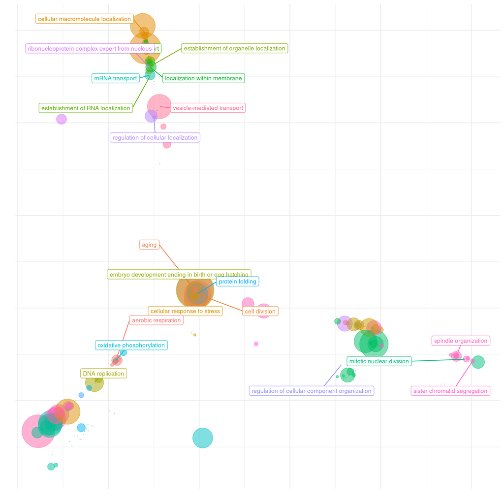

```r
# C. elegans unc-55
scatterPlot(GO_sum$Ce_simMatrix, GO_sum$Ce_reducedTerms)
```

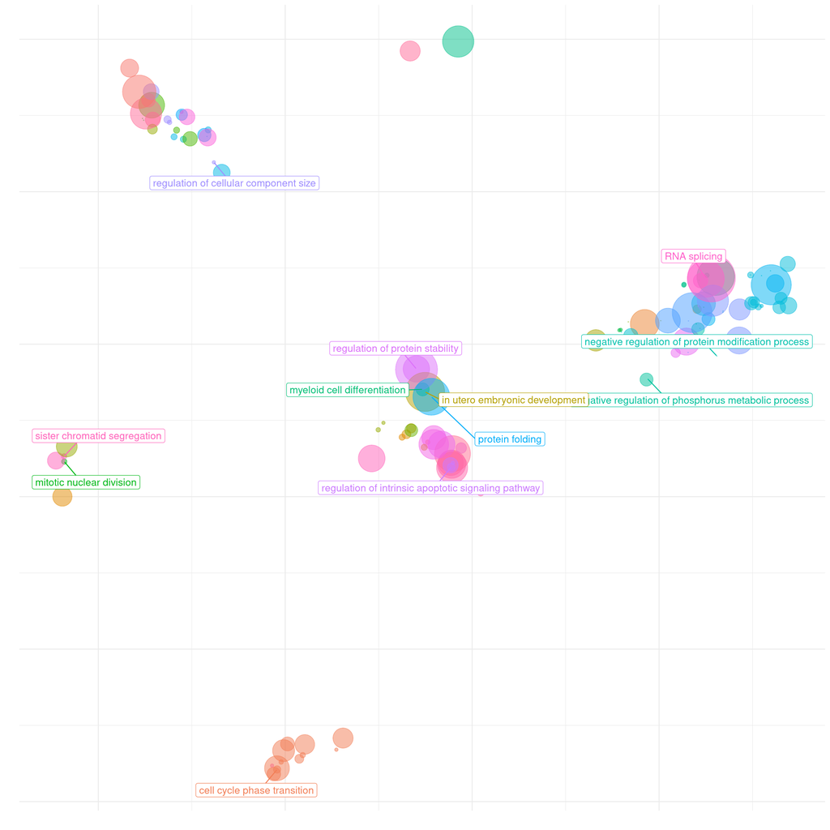

```r
# human NR2F1
scatterPlot(GO_sum$Hs_simMatrix, GO_sum$Hs_reducedTerms, labelSize = 4)
```

Let’s plot the main *GO* results that appeared to be common in the overrepresentation an summarisation analyses of the target genes of the *C. elegans* **unc-55** and the human **NR2F1** transcription factors.

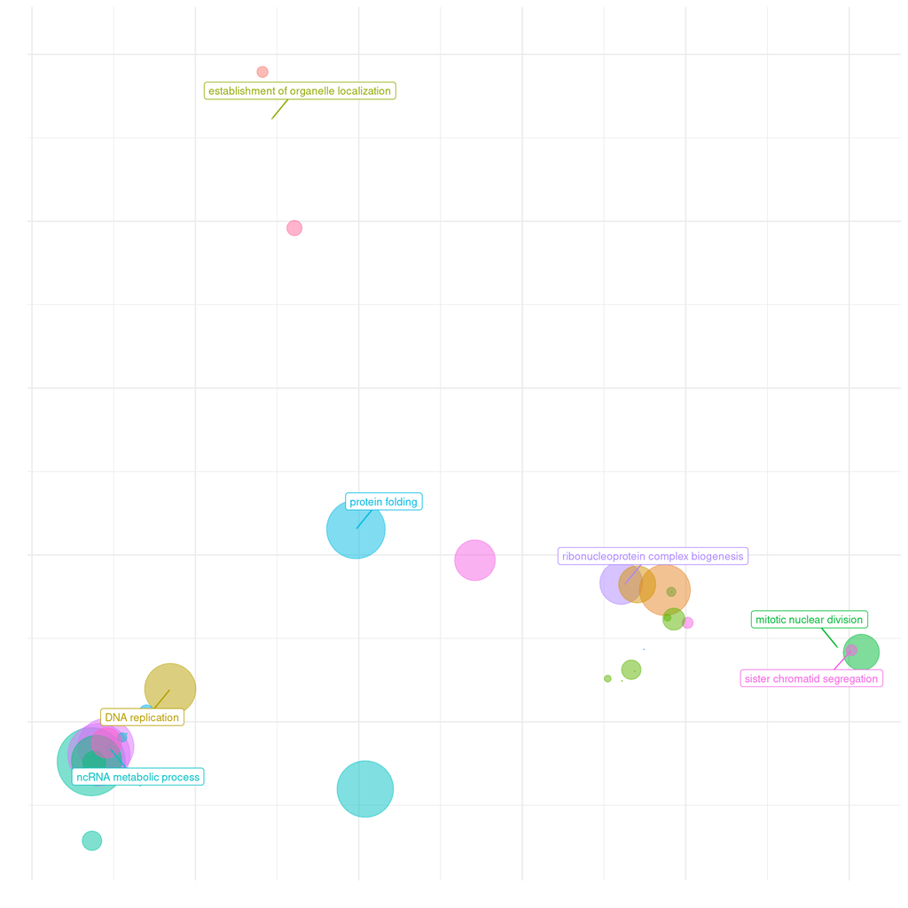

```r
# Filtering and plotting the common GO results
GO_sum$Ce_reducedTerms %>%
  filter(go %in% GO_sum$Hs_reducedTerms$go) %>%
  scatterPlot(GO_sum$Ce_simMatrix, .)
```

As we can see there are several conserved functions, and even more that diverged during the evolution the this transcription factor.

# 4 Environment

In this *use case* the following software and package versions were applied:

- `R` version 4.1.3
- `tidyverse` version 1.3.1
- `data.table` version 1.14.2
- `clusterProfiler` version 4.2.2
- `org.Ce.eg.db` version 3.14.0
- `org.Hs.eg.db` version 3.14.0
- `rrvgo` version 1.6.0